# 김광수_사례연구

김광수

2021 3 8

```r
library(dplyr)
```

```r
library(ggplot2)
library(doBy)
library(foreign)
```

# 사례연구

## 문1

### 한국복지패널데이터’(SPSS, koweps_hpc10_2015_beta5.sav)를 로드한 후 필요한 데이터 변수만을 select하여 변수명을 변경하시오. 단 필요한 필드로 성별은 gender, 태어난 연도는 birth, 혼인상태는 marriage, 종교는 religion, 월평균임금은 income, 직업코드는 code_job, 지역코드는 code_region로 필드명을 변경한다.

```r
raw_welfare <- read.spss(file='inData/Koweps/Koweps_hpc10_2015_beta1.sav', to.data.frame = T)
welfare<-raw_welfare
welfare<-welfare[,c('h10_g3','h10_g4','h10_g10','h10_g11','h10_eco9','p1002_8aq1','h10_reg7')]
names(welfare)<-c('gender','birth','marriage','religion','code_job','income','code_region')
colnames(welfare)
```

```
## [1] "gender"      "birth"       "marriage"    "religion"    "code_job"
## [6] "income"      "code_region"
```

## 문2

### 1번 문제의 결과인 data.frame변수를 이용하여 성별에 따른 월급 차이가 있는지를 분석하시오.

```r
table(is.na(welfare$gender))
```

```
##
## FALSE
## 16664
```

```r
welfare$gender<-gsub(1,'male',x=welfare$gender)
welfare$gender<-gsub(2,'female',x=welfare$gender)
welfare$gender<-as.factor(welfare$gender)

allg<-sum(table(welfare$gender))
m<-table(welfare$gender)[1]
f<-table(welfare$gender)[2]

welfare%>%
    select(gender)%>%
    summarise(female=(f/allg)*100,
              male=(m/allg)*100)
```

```
##     female     male
## 1 45.47528 54.52472
```

```r
ratio<- (c(f,m)/allg*100)
```

#### 성별비율도표와 그래프

```r
ratio
```

```
##     male   female
## 45.47528 54.52472
```

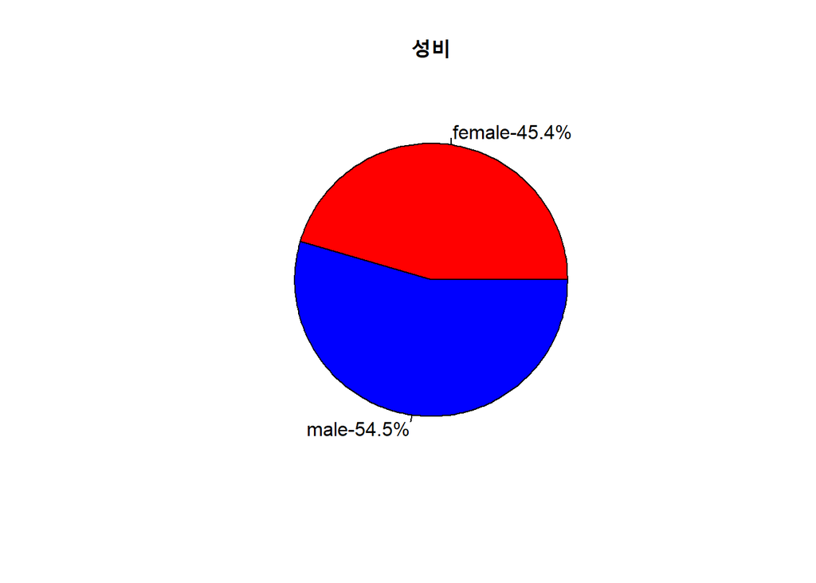

```r
pie(ratio,col=c('red','blue'),labels=c('female-45.4%','male-54.5%') ,main='성비')
```

#### 월급의 빈도그래프

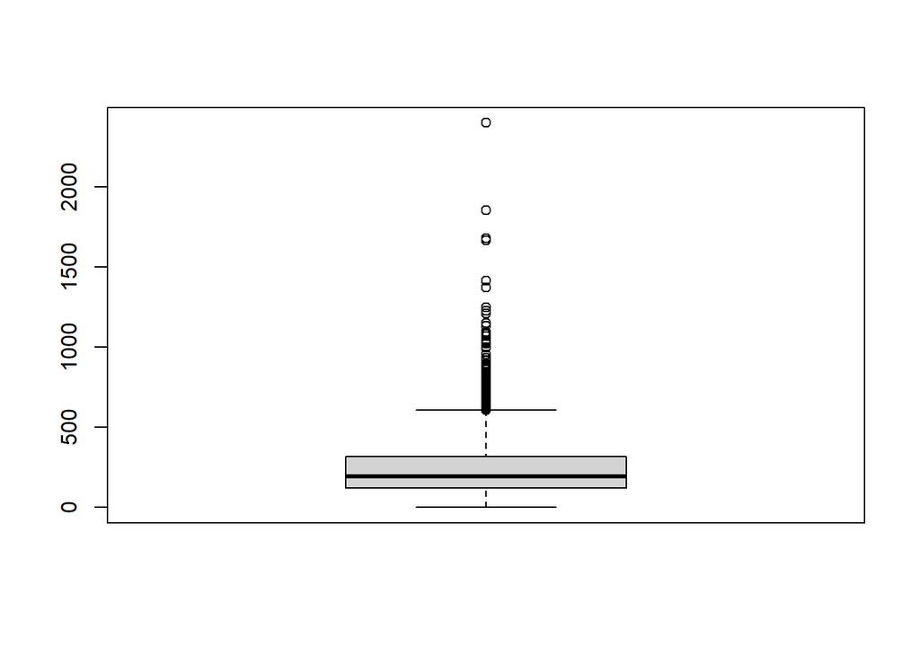

```r
boxplot(welfare$income)
```

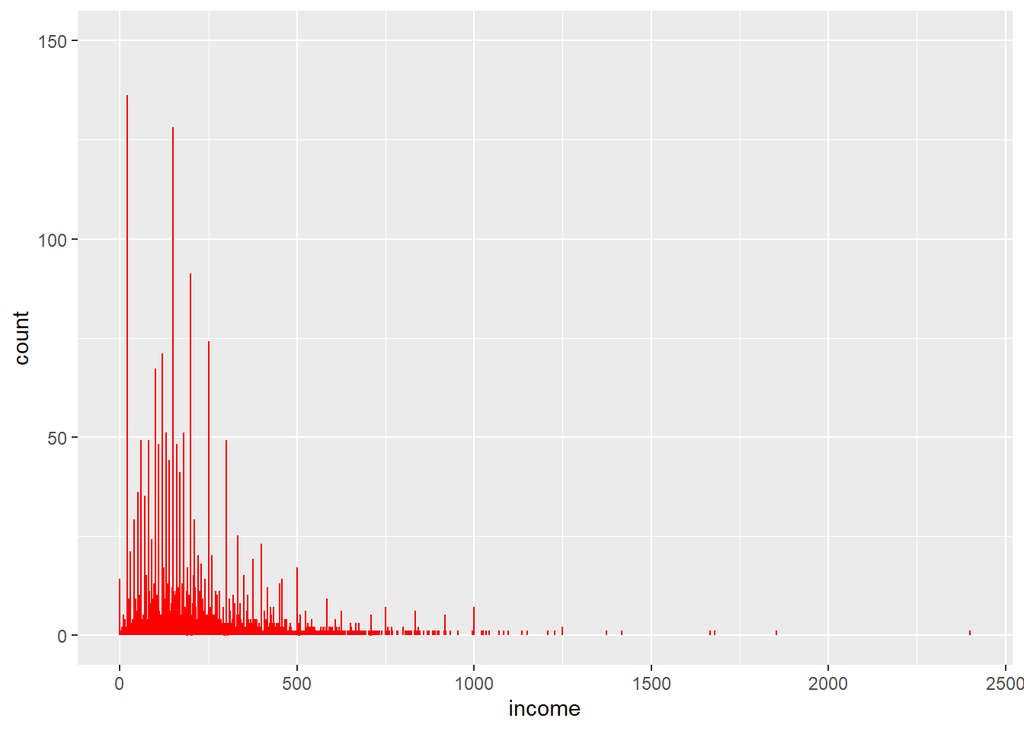

```r
ggplot(welfare,aes(income))+
    geom_bar(col='red',na.rm=T)+
    coord_cartesian(ylim = c(0,150))
```

#### 최종분석

```r
welfare$income<- ifelse(welfare$income==0,NA,welfare$income)
welfare$income<- ifelse(welfare$income>1300,NA,welfare$income)

##단순도표
summaryBy(income~gender,welfare,FUN=c(mean,sd),na.rm=T)
```

```
##   gender income.mean income.sd
## 1 female    162.2149  116.5593
## 2   male    309.1115  188.0723
```

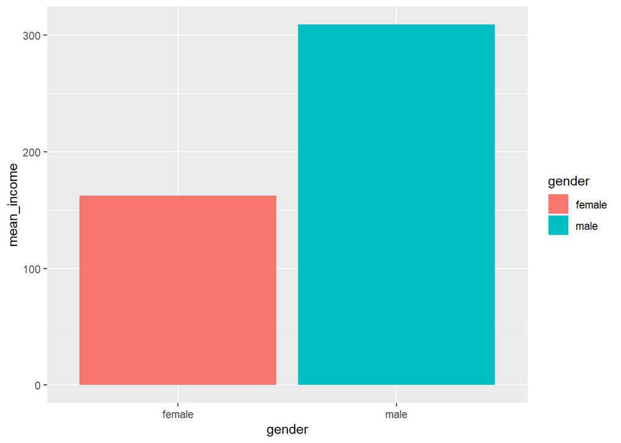

```r
##평균차
welfare%>%
    filter(!is.na(income))%>%
    group_by(gender)%>%
    summarise(mean_income=mean(income))%>%
    ggplot(aes(x=gender,y=mean_income))+
    geom_col(aes(fill=gender))
```

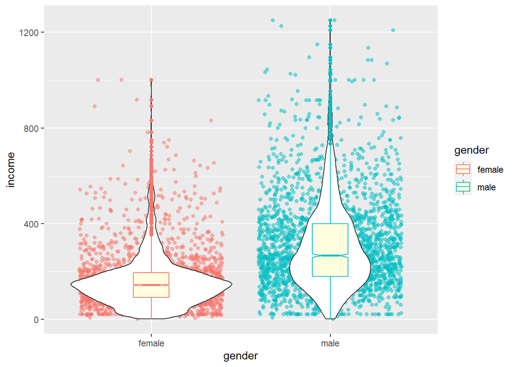

```r
##표본차
ggplot(welfare,aes(x=gender,y=income))+
    geom_point(aes(col=gender),position="jitter",alpha=0.5)+
    geom_violin()+
    geom_boxplot(width=0.2,aes(col=gender),fill='lightyellow',notch=T)
```

```r
##통계적 유의미 분석
var.test(income~gender,welfare)
```

```
##
##  F test to compare two variances
##
## data:  income by gender
## F = 0.3841, num df = 2166, denom df = 2445, p-value < 2.2e-16
## alternative hypothesis: true ratio of variances is not equal to 1
## 95 percent confidence interval:
##  0.3539643 0.4168863
## sample estimates:
## ratio of variances
##          0.3840997
```

```r
# p-value가 0.05 보다 작음으로 귀무가설을 기각
t.test(income~gender,welfare,var.equal=F)
```

```
##
##  Welch Two Sample t-test
##
## data:  income by gender
## t = -32.263, df = 4145.1, p-value < 2.2e-16
## alternative hypothesis: true difference in means is not equal to 0
## 95 percent confidence interval:
##  -155.8231 -137.9702
## sample estimates:
## mean in group female   mean in group male
##             162.2149             309.1115
```

```r
2.2e-16<0.05
```

```
## [1] TRUE
```

```r
# p-value가 0.05 보다 작음으로 귀무가설을 기각한다. 성별에 따른 월급차이가 있다.
```